# Assignment2

U7457462_Sihao_Yang

2022-10-25

# Assignment2: Statistical Analysis and Interpretation

## 1. Correct analysis of *Clark et al. (2020)* data to generate the summary statistics (means, SD, N) for each of the fish species’ average activity for each treatment.

### Libraries and Packages

Load in the corresponding libraries, `tidyverse`, `readxl`, `metafor`,`metadat` and so on.

```r
library(tidyverse)
library(readr)
install.packages("pacman", repos = "http://cran.us.r-project.org")
library(pacman)
p_load(bookdown, tidyverse, ggforce, flextable, latex2exp, png, magick) # list all the packages
library(puniform) #Load puniform
library(metadat)
library(metafor)
library(orchaRd)
```

### Import CSV files

```r
data_Clark_path <- "data/OA_activitydat_20190302_BIOL3207.csv"
data_Clark <- read_csv(data_Clark_path)
```

```
## ──────────────────────────────────────────────────────── Delimiter: "," chr
## (5): loc, species, treatment, size, comment dbl (4): ...1, animal_id, sl,
## activity
```

```r
head(data_Clark)
```

```
## # A tibble: 6 × 9
##    ...1 loc       species treatment animal_id    sl size  activity comment
##   <dbl> <chr>     <chr>   <chr>         <dbl> <dbl> <chr>    <dbl> <chr>
## 1     1 LIRS 2014 ambon   CO2              64  57.0 big       8.15 27min means …
## 2     2 LIRS 2014 ambon   CO2              65  38.2 big      10.5  27min means …
## 3     3 LIRS 2014 ambon   CO2              67  39.3 big       6.51 27min means …
## 4     4 LIRS 2014 ambon   CO2              68  36.1 big      27.8  27min means …
## 5     5 LIRS 2014 lemon   CO2              74  36.4 big      36.7  27min means …
## 6     6 LIRS 2014 ambon   CO2              75  35.9 big      42.8  27min means …
```

### Remove the NAs

First, write some code below to remove missing data

```r
# Code to removing missing data from the `OA_activitydat_20190302_BIOL3207.csv` data frame.
data_Clark <- na.omit(data_Clark)
```

### Create the table of summary statisitics of mean/SD/N of data

```r
# Use flextable to render the summary table in a tidy format
mean_sd <- list(mean=~mean(.x, na.rm = TRUE),
  sd = ~sd(.x, na.rm = TRUE)
)
data_Clark_mean_sd <- data_Clark %>% select(species,treatment,sl,size,activity) %>% group_by(species,treatment,size)%>% summarise(across(where(is.numeric), mean_sd),N=n())
data_Clark_mean_sd%>% flextable(,col_keys = c("species","treatement","size","sl_mean","sl_sd","activity_mean","activity_sd","N")) %>% add_header_row(, values = c("", "sl","activity",""), colwidths = c(3, 2,2,1)) %>% align(, i = 1, part = "header", align = "center")
```

sumtable

| species |  | size | sl sl_mean | sl sl_sd | activity activity_mean | activity activity_sd | N |
| --- | --- | --- | --- | --- | --- | --- | --- |
| acantho |  | big | 38.740561 | 22.7614943 | 30.57666 | 12.989838 | 24 |
| acantho |  | small | 10.516129 | 1.9793353 | 26.03221 | 9.038057 | 62 |
| acantho |  | big | 39.774079 | 22.3553773 | 24.65294 | 15.205429 | 27 |
| acantho |  | small | 10.984127 | 2.0180002 | 30.75787 | 8.558162 | 63 |
| ambon |  | big | 37.465144 | 6.9427778 | 18.39429 | 12.200326 | 22 |
| ambon |  | big | 38.502189 | 7.7049414 | 17.34102 | 11.451588 | 21 |
| chromis |  | big | 31.954830 | 11.9496994 | 24.78010 | 10.975005 | 14 |
| chromis |  | big | 33.430978 | 8.3876113 | 26.09986 | 9.125352 | 20 |
| humbug |  | big | 31.686427 | 11.4876918 | 40.28306 | 11.915992 | 62 |
| humbug |  | big | 31.774324 | 10.9664192 | 34.91652 | 13.867278 | 65 |
| lemon |  | big | 28.818171 | 3.8804576 | 26.04157 | 10.957164 | 19 |
| lemon |  | big | 28.846683 | 4.7748537 | 19.79766 | 12.256353 | 30 |
| whitedams |  | big | 21.981481 | 4.7767093 | 19.01736 | 7.151807 | 27 |
| whitedams |  | small | 8.333333 | 0.5253967 | 28.90822 | 9.777271 | 33 |
| whitedams |  | big | 22.166667 | 6.2322211 | 20.39650 | 7.284379 | 24 |
| whitedams |  | small | 8.648649 | 1.0332316 | 30.60121 | 11.105763 | 37 |

## 2.Through coding, merge the summary statistics generated from 1) with the metadata from *Clark et al. (2020)*.

### Make the tibble tidy and rename the columns

```r
# calculate mean/SD/N of activity group by treatment
data_Clark_activity_mean_sd <- data_Clark %>% select(species,treatment,activity) %>% group_by(species,treatment)%>% summarise(across(where(is.numeric), mean_sd),N=n())
# use `pivot_wider()` to separate the activity value of treatment
data_Clark_activity_mean_sd <- data_Clark_activity_mean_sd %>% pivot_wider(names_from = treatment,values_from =c(activity_mean,activity_sd,N) )
# rename the columns
names(data_Clark_activity_mean_sd) <-c('Species','oa.mean','ctrl.mean','oa.sd','ctrl.sd','oa.n','ctrl.n')
data_Clark_activity_mean_sd
```

```
## # A tibble: 6 × 7
## # Groups:   Species [6]
##   Species   oa.mean ctrl.mean oa.sd ctrl.sd  oa.n ctrl.n
##   <chr>       <dbl>     <dbl> <dbl>   <dbl> <int>  <int>
## 1 acantho      27.3      28.9 10.4    11.2     86     90
## 2 ambon        18.4      17.3 12.2    11.5     22     21
## 3 chromis      24.8      26.1 11.0     9.13    14     20
## 4 humbug       40.3      34.9 11.9    13.9     62     65
## 5 lemon        26.0      19.8 11.0    12.3     19     30
## 6 whitedams    24.5      26.6  9.95   10.9     60     61
```

```r
# read the CSV file
paper_path <- "./data/clark_paper_data.csv"
ocean_paper <- read_csv(paper_path)
# replace NA with '-'
ocean_paper <- ocean_paper %>% mutate_at('Cue/stimulus type', ~replace(., is.na(.), '-'))
# merge the tibbles into the metadata
Clark_meta_data <- cbind(ocean_paper,data_Clark_activity_mean_sd)
```

## 3. Through coding, correctly merge the combined summary statistics and metadata from *Clark et al. (2020)* (output from 1 & 2) into the larger meta-analysis dataset .

### Import and merge the file

```r
# read the file
ocean_meat_path <- "./data/ocean_meta_data.csv"
ocean_meat_data <- read_csv(ocean_meat_path)
# merge with Clark_meata_data
ocean_meta_data <- rbind(ocean_meat_data,Clark_meta_data)
# eliminate some unresonable data
ocean_meta_data <- ocean_meta_data %>% filter(ctrl.mean>0,oa.mean>0)
colnames(ocean_meta_data)[14] <- 'sti_type'
# Add in observation-level (residual) column. This column simply counts, from 1 to the number of rows
ocean_meta_data <- ocean_meta_data %>% mutate(residual = 1:n()) # Add this observation level variable.
head(ocean_meta_data)
```

```
## # A tibble: 6 × 23
##   Study Authors    Year …¹ Year …² Title Journal Pub y…³ 2017 …⁴ Avera…⁵ Effec…⁶
##   <chr> <chr>        <dbl>   <dbl> <chr> <chr>   <chr>   <chr>     <dbl> <chr>
## 1 a1    Munday et…    2009    2009 Ocea… PNAS    9.432   9.504        27 Strong
## 2 a1    Munday et…    2009    2009 Ocea… PNAS    9.432   9.504        27 Strong
## 3 a1    Munday et…    2009    2009 Ocea… PNAS    9.432   9.504        27 Strong
## 4 a1    Munday et…    2009    2009 Ocea… PNAS    9.432   9.504        27 Strong
## 5 a1    Munday et…    2009    2009 Ocea… PNAS    9.432   9.504        27 Strong
## 6 a1    Munday et…    2009    2009 Ocea… PNAS    9.432   9.504        27 Strong
## # … with 13 more variables: Species <chr>, `Climate (FishBase)` <chr>,
## #   `Env cue/stimulus?` <chr>, sti_type <chr>, `Behavioural metric` <chr>,
## #   `Life stage` <chr>, ctrl.n <dbl>, ctrl.mean <dbl>, ctrl.sd <dbl>,
## #   oa.n <dbl>, oa.mean <dbl>, oa.sd <dbl>, residual <int>, and abbreviated
## #   variable names ¹`Year (online)`, ²`Year (print)`, ³`Pub year IF`,
## #   ⁴`2017 IF`, ⁵`Average n`, ⁶`Effect type`
```

## 4. Correctly calculate the log response ratio (lnRR) effect size for every row of the dataframe using metafor’s `escalc()` function.

### Use `escalc` function with the measure ‘ROM’

```r
# calculate the log response ratio (lnRR) effect size
lnRR <- metafor::escalc(measure='ROM',
                        n1i = ocean_meta_data$ctrl.n ,n2i=ocean_meta_data$oa.n ,
                        m1i=ocean_meta_data$ctrl.mean ,m2i= ocean_meta_data$oa.mean ,
                        sd1i=ocean_meta_data$ctrl.sd,sd2i=ocean_meta_data$oa.sd,
                        var.names=c("yi","vi"),data = ocean_meta_data,
                        slab=paste(ocean_meta_data$Authors,ocean_meta_data$`Year (online)`,sep = ","))
view(lnRR)# view the lnRR data
```

## 5. Correct meta-analytic model fitted to the data that controls for the sampling variance of lnRR. The model should include a random effect of study and observation. Use metafor’s `rma.mv()` function.

### Create the model

```r
# use `rma.mv()` function with random effect of 'Study' and 'residual'
MLMA <- metafor::rma.mv(lnRR$yi,lnRR$vi,random = list(~1|Study,~1|residual),test="t",data = ocean_meta_data)
MLMA
```

```
##
## Multivariate Meta-Analysis Model (k = 764; method: REML)
##
## Variance Components:
##
##             estim    sqrt  nlvls  fixed    factor
## sigma^2.1  0.4773  0.6909     92     no     Study
## sigma^2.2  4.1474  2.0365    764     no  residual
##
## Test for Heterogeneity:
## Q(df = 763) = 736088769.0061, p-val < .0001
##
## Model Results:
##
## estimate      se     tval   df    pval    ci.lb   ci.ub
##  -0.1424  0.1152  -1.2360  763  0.2168  -0.3686  0.0838
##
## ---
## Signif. codes:  0 '***' 0.001 '**' 0.01 '*' 0.05 '.' 0.1 ' ' 1
```

## 6.Written paragraph of the findings and what they mean which is supported with a figure. The paragraph should include:

### Correct presentation and interpretation of overall meta-analytic mean and measures of uncertainty around the mean estimate (e.g., 95% confidence intervals).

#### Use `predict()` function

```r
pre1 <- predict(MLMA,digits = 3)
pre1
```

```
##
##    pred    se  ci.lb ci.ub  pi.lb pi.ub
##  -0.142 0.115 -0.369 0.084 -4.370 4.085
```

#### Plot the predictions and see if they are inside the confidence interval

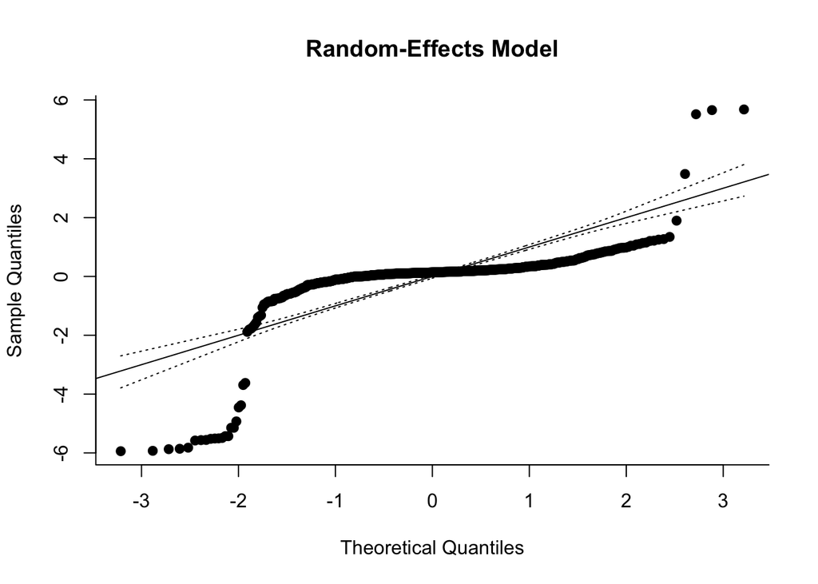

95CIfig

```r
# qq-normal plots
res <- rma(yi, vi, data =lnRR)
qqnorm(res, main = "Random-Effects Model")
```

To check whether the data violate the normal distribution assumption of the random effects model The points are not all within the dotted line(95% CI), which means they do not conform to a normal distribution

### Measures of heterogeneity in effect size estimates across studies (i.e., I^2 and/or prediction intervals - see `predict()` function in metafor)

```r
i2_vals <- orchaRd::i2_ml(MLMA)
i2 <- tibble(type = firstup(gsub("I2_", "", names(i2_vals))), I2 = i2_vals)
flextable(i2) %>%
    align(part = "header", align = "center") %>%
    compose(part = "header", j = 1, value = as_paragraph(as_b("Type"))) %>%
    compose(part = "header", j = 2, value = as_paragraph(as_b("I"), as_b(as_sup("2")),
        as_b("(%)")))
```

I2table

| Type | I2(%) |
| --- | --- |
| Total | 100.00000 |
| Study | 10.32165 |
| Residual | 89.67835 |

```r
pre1 <- predict(MLMA)
pre1
```

```
##
##     pred     se   ci.lb  ci.ub   pi.lb  pi.ub
##  -0.1424 0.1152 -0.3686 0.0838 -4.3701 4.0853
```

### Forest plot showing the mean estimate, 95% confidence interval, and prediction interval with clearly labelled axes, number of samples and studies plotted on figure

#### Make forest plot

[figure not shown]

forefig

```r
forest(MLMA,slab = paste(ocean_meta_data$Authors,
                    as.character(ocean_meta_data$`Year (online)`), sep = ", "),  header="Author(s) and Year")
```

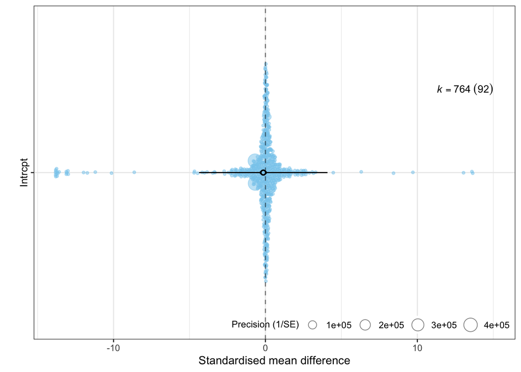

orchfig

```r
orchaRd::orchard_plot(MLMA, mod="1", data = ocean_meta_data, group = "Study", xlab = "Standardised mean difference",
  transfm = "none")
```

## 7. Funnel plot for visually assessing the possibility of publication bias.

### Make funnel plot

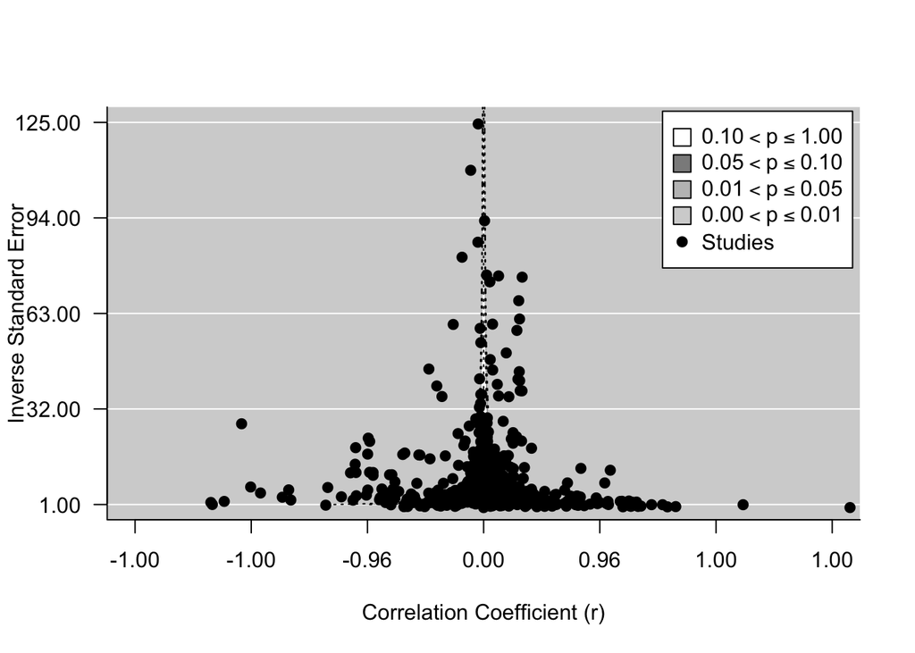

fun1fig

```r
# make a funnel plot to visualize the data in relation to the precision,
# inverse sampling standard error,
metafor::funnel(x = lnRR$yi, vi = lnRR$vi, yaxis = "seinv",
    digits = 2, level = c(0.1, 0.05, 0.01), shade = c("white", "gray55", "gray 75"),
    las = 1, xlab = "Correlation Coefficient (r)", atransf = tanh, legend = TRUE,xlim=c(-6,6),ylim=c(1,125))
```

### Fitting a Multilevel Meta-Regression model to Test and Correct for Publication bias

```r
MLMA2 <- metafor::rma.mv(lnRR$yi,lnRR$vi,
                         random = ~Study|residual,
                         mods = ~`Year (online)`,
                         test="t",data = ocean_meta_data)
MLMA2
```

```
##
## Multivariate Meta-Analysis Model (k = 764; method: REML)
##
## Variance Components:
##
## outer factor: residual (nlvls = 764)
## inner factor: Study    (nlvls = 92)
##
##             estim    sqrt  fixed
## tau^2      4.8018  2.1913     no
## rho        0.0000            yes
##
## Test for Residual Heterogeneity:
## QE(df = 762) = 128790346.4998, p-val < .0001
##
## Test of Moderators (coefficient 2):
## F(df1 = 1, df2 = 762) = 44.7892, p-val < .0001
##
## Model Results:
##
##                   estimate       se     tval   df    pval      ci.lb      ci.ub
## intrcpt          -385.9600  57.6283  -6.6974  762  <.0001  -499.0890  -272.8311
## `Year (online)`     0.1914   0.0286   6.6925  762  <.0001     0.1353     0.2475
##
## intrcpt          ***
## `Year (online)`  ***
##
## ---
## Signif. codes:  0 '***' 0.001 '**' 0.01 '*' 0.05 '.' 0.1 ' ' 1
```

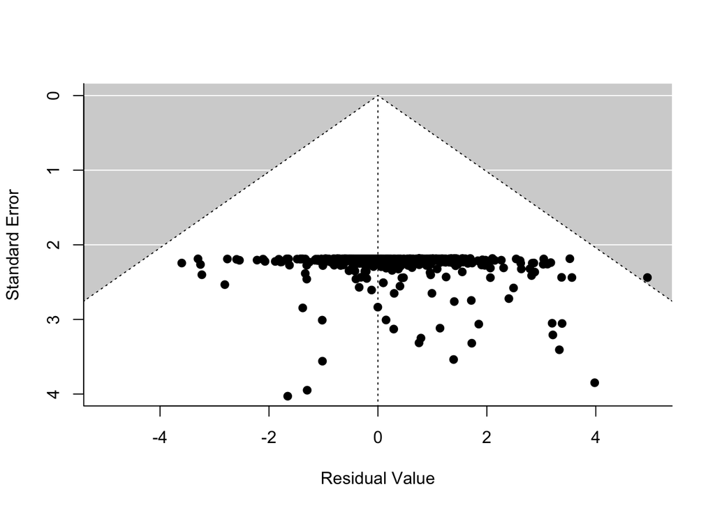

fun2fig

```r
funnel(MLMA2,xlim=c(-5,5),ylim=c(0,4))
```

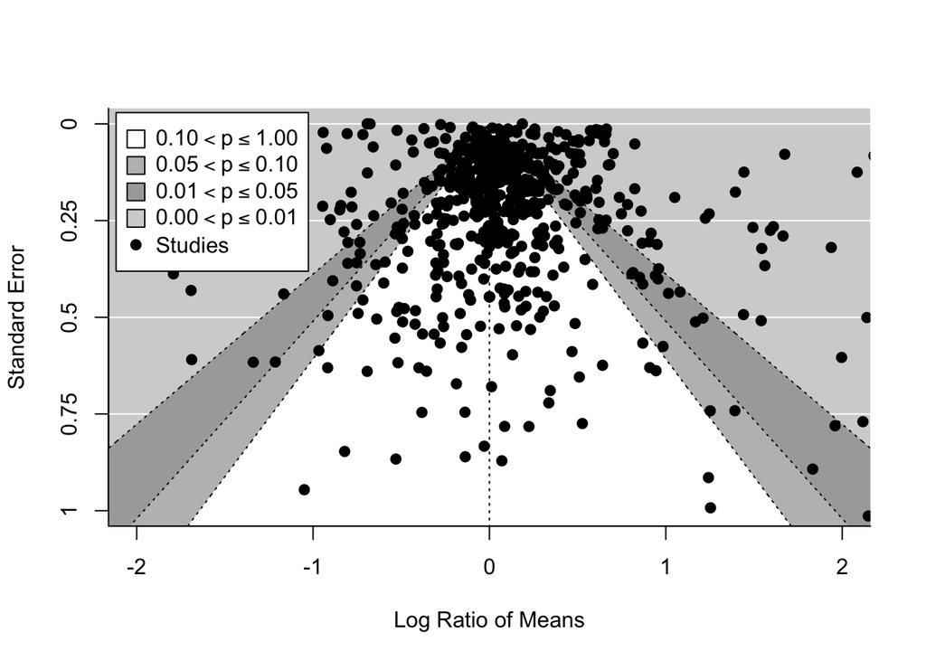

fun2fig

```r
# Lets make a funnel plot to visualize the data in relation to the precision, inverse sampling standard error,
metafor::funnel(MLMA,refline=0,xlim=c(-2,2),ylim=c(0,1), level=c(90, 95, 99),
       shade=c("white", "gray", "darkgray"),  legend="topleft")
```

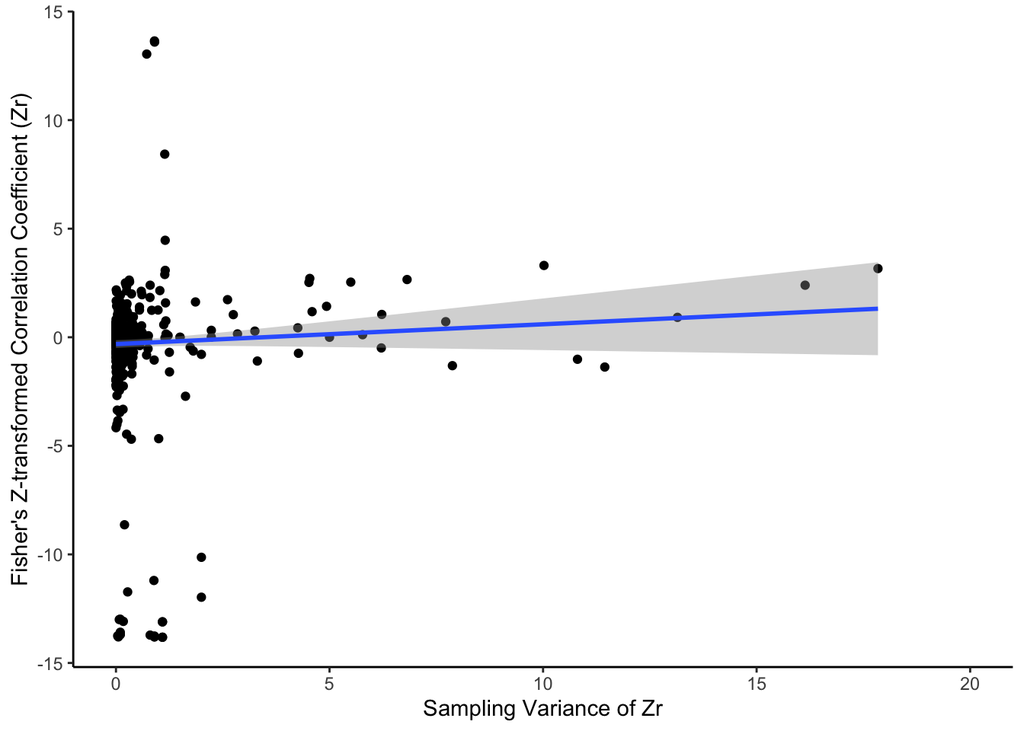

fun3fig

```r
# flip around the funnel plot
ggplot(lnRR, aes(y = lnRR$yi, x = lnRR$vi)) + geom_point() + geom_smooth(method = lm) +
    labs(y = "Fisher's Z-transformed Correlation Coefficient (Zr)", x = "Sampling Variance of Zr") +
    theme_classic()+xlim(c(0,20))
```

```r
# Detection of publication bias
ranktest(MLMA)
```

```
##
## Rank Correlation Test for Funnel Plot Asymmetry
##
## Kendall's tau = -0.5606, p < .0001
```

The rank correlation test detects whether the observed effect size is significantly related to the corresponding sample variance. The correlation is significant, which means that there are small-study effects(small sample size & large effect size).

## 8.Time-lag plot assessing how effect sizes may or may not have changed through time.

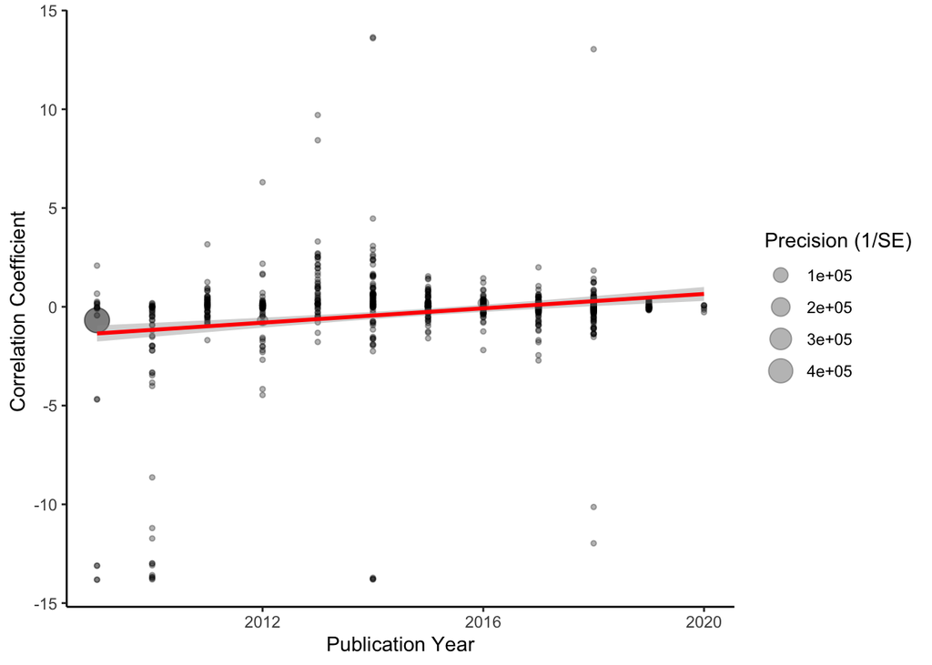

timelagfig

```r
ggplot(lnRR, aes(y = yi, x = ocean_meta_data$`Year (online)`, size = 1/sqrt(vi))) + geom_point(alpha = 0.3) +
    geom_smooth(method = lm, col = "red", show.legend = FALSE) + labs(x = "Publication Year",
    y = "Correlation Coefficient ", size = "Precision (1/SE)") +
    theme_classic()
```

```r
# Quantifying time lag bias using multilevel meta-regression

metareg_time <- rma.mv(lnRR$yi ~ ocean_meta_data$`Year (online)`, V = lnRR$vi, random = list(~1 | Study, ~1 |residual),test = "t", dfs = "contain", data = ocean_meta_data)# Including sampling variance as moderator
summary(metareg_time)
```

```
##
## Multivariate Meta-Analysis Model (k = 764; method: REML)
##
##     logLik    Deviance         AIC         BIC        AICc
## -1717.3679   3434.7359   3442.7359   3461.2797   3442.7887
##
## Variance Components:
##
##             estim    sqrt  nlvls  fixed    factor
## sigma^2.1  0.3880  0.6229     92     no     Study
## sigma^2.2  4.1482  2.0367    764     no  residual
##
## Test for Residual Heterogeneity:
## QE(df = 762) = 128790346.4998, p-val < .0001
##
## Test of Moderators (coefficient 2):
## F(df1 = 1, df2 = 90) = 8.5206, p-val = 0.0044
##
## Model Results:
##
##                                   estimate       se     tval  df    pval
## intrcpt                          -241.5280  82.6918  -2.9208  90  0.0044
## ocean_meta_data$`Year (online)`     0.1198   0.0410   2.9190  90  0.0044
##                                      ci.lb     ci.ub
## intrcpt                          -405.8098  -77.2463  **
## ocean_meta_data$`Year (online)`     0.0383    0.2013  **
##
## ---
## Signif. codes:  0 '***' 0.001 '**' 0.01 '*' 0.05 '.' 0.1 ' ' 1
```